# Severe Weather Events in the US between 1950 and 2011: Proportion of Damage to Property and Public Health

Ariel Lev

April 22nd, 2015

### Data Processing

Loading required packages.

```r
require(dplyr)
require(ggplot2)
require(stringr)
require(reshape2)
```

Loading the dataset into R

```r
# loading the dataset into R
d <- read.csv(bzfile("storm.bz2"), stringsAsFactors=F)

# dataset was downloaded from: "https://d396qusza40orc.cloudfront.net/repdata%2Fdata%2FStormData.csv.bz2"
# dataset was downloaded on:   "2015-04-18 07:37:06 CEST"

# exploring dimensions and variables
str(d)
```

```
## 'data.frame':    902297 obs. of  37 variables:
##  $ STATE__   : num  1 1 1 1 1 1 1 1 1 1 ...
##  $ BGN_DATE  : chr  "4/18/1950 0:00:00" "4/18/1950 0:00:00" "2/20/1951 0:00:00" "6/8/1951 0:00:00" ...
##  $ BGN_TIME  : chr  "0130" "0145" "1600" "0900" ...
##  $ TIME_ZONE : chr  "CST" "CST" "CST" "CST" ...
##  $ COUNTY    : num  97 3 57 89 43 77 9 123 125 57 ...
##  $ COUNTYNAME: chr  "MOBILE" "BALDWIN" "FAYETTE" "MADISON" ...
##  $ STATE     : chr  "AL" "AL" "AL" "AL" ...
##  $ EVTYPE    : chr  "TORNADO" "TORNADO" "TORNADO" "TORNADO" ...
##  $ BGN_RANGE : num  0 0 0 0 0 0 0 0 0 0 ...
##  $ BGN_AZI   : chr  "" "" "" "" ...
##  $ BGN_LOCATI: chr  "" "" "" "" ...
##  $ END_DATE  : chr  "" "" "" "" ...
##  $ END_TIME  : chr  "" "" "" "" ...
##  $ COUNTY_END: num  0 0 0 0 0 0 0 0 0 0 ...
```

[output cut: 23 more lines]

The variables, on which our assessments essentially depends on, are listed in the table below. The rest of the variables can be ignored for the scope of our study - making our dataset more lightweight to work with.

| variable | description |
| --- | --- |
| EVTYPE | event type |
| FATALITIES | total fatalities |
| INJURIES | total injuries |
| PROPDMG | property damage - mantissa |
| PROPDMGEXP | property damage - exponent |
| CROPDMG | crop damage - mantissa |
| CROPDMGEXP | crop damage - exponent |
| REMARKS | additional information* |

- REMARKS is necessary in cases where EVTYPE is of a form of “Summary of..”

```r
# projecting dataset
cols <- c(8,23:28,36)
d <- d[,cols]
names(d)
```

```
## [1] "EVTYPE"     "FATALITIES" "INJURIES"   "PROPDMG"    "PROPDMGEXP"
## [6] "CROPDMG"    "CROPDMGEXP" "REMARKS"
```

Lets see how many types of events are listed in the dataset.

```r
e_types <- d$EVTYPE
length(unique(e_types))
```

```
## [1] 985
```

After a short examination of the size of the unique values of EVTYPE, it turns out that the figure is fairly bigger than the 48 permitted events by NOAA. We will therefore have to tidy up EVTYPE, and align it with the data provided by **Table 1**

### Cleaning EVTYPE

In this section I would like to demonstrate a method to clean EVTYPE. The strategy would be in general to **automatically** find a best match between a given EVTYPE to a possible candidate in **Table 1**. For that purpose I will introduce a simple yet powerful utility function called *noaa_match*. Prior to finding a match, we will have to reduce the noise, i.e terms extrinsic to **Table 1** ( lets say “Chocolate” or “Beer”) - will have to be completely remove, and those that hold certain similarities will be transformed. This first goal will be achieved by introducing another function called *noaa_filter*, and the latter by applying basic techniques of string manipulations. Although my objective was to fully automate this whole process, the first step - copying the data from the pdf, will be involved with a manual step.

#### Step 1: Basic string manipulations

```r
# applying string manipulation to clean the EVTYPE variable
# upper Case
e_types <- toupper(e_types)
# removing non alphabetical chars
e_types <- gsub("[^A-Z ]", " ",  e_types)
# removing spaces
e_types <- gsub("[ ]+", " ",  e_types)
# trimming
e_types <- str_trim(e_types)

length(unique(e_types))
```

```
## [1] 714
```

#### Step 2: Copy Table 1

I opened [National Weather Service Instruction 10-1605.pdf](https://d396qusza40orc.cloudfront.net/repdata%2Fpeer2_doc%2Fpd01016005curr.pdf) and scrolled down to page 6 to **Table 1 *Storm Data***, copied the table into *“noaa_e_types.txt”*, a file I created in my working directory. After processing the file’s data, I created two R variables *noaa_glossary* and *noaa_e_types*

```r
system("head noaa_e_types.txt")
# Astronomical Low Tide Z
# Avalanche Z
# Blizzard Z
# Coastal Flood Z
# Cold/Wind Chill Z
# Debris Flow C
# Dense Fog Z
# Dense Smoke Z
# Drought Z
# Dust Devil C

# noaa_glossary is the word set of Table 1
noaa_glossary <- scan("noaa_e_types.txt", what = "characters")
noaa_glossary <- unique(noaa_glossary)
noaa_glossary <- unlist(strsplit(noaa_glossary,"[^a-zA-Z]", fixed=F))
noaa_glossary <- noaa_glossary[nchar(noaa_glossary) > 1]
noaa_glossary <- toupper(noaa_glossary)
noaa_glossary <- noaa_glossary[order(noaa_glossary)]
noaa_glossary
```

```
##  [1] "ASH"          "ASTRONOMICAL" "AVALANCHE"    "BLIZZARD"
##  [5] "CHILL"        "CLOUD"        "COASTAL"      "COLD"
##  [9] "CURRENT"      "DEBRIS"       "DENSE"        "DEPRESSION"
## [13] "DEVIL"        "DROUGHT"      "DUST"         "EFFECT"
## [17] "EXCESSIVE"    "EXTREME"      "FLASH"        "FLOOD"
## [21] "FLOW"         "FOG"          "FREEZE"       "FREEZING"
## [25] "FROST"        "FUNNEL"       "HAIL"         "HEAT"
## [29] "HEAVY"        "HIGH"         "HURRICANE"    "ICE"
## [33] "LAKE"         "LAKESHORE"    "LIGHTNING"    "LOW"
## [37] "MARINE"       "RAIN"         "RIP"          "SEICHE"
## [41] "SLEET"        "SMOKE"        "SNOW"         "STORM"
## [45] "STRONG"       "SURF"         "SURGE"        "THUNDERSTORM"
## [49] "TIDE"         "TIDE"         "TORNADO"      "TROPICAL"
## [53] "TSUNAMI"      "TYPHOON"      "VOLCANIC"     "WATERSPOUT"
## [57] "WEATHER"      "WILDFIRE"     "WIND"         "WIND"
## [61] "WINTER"
```

```r
# noaa_e_types is a set of permitted event types as listed in Table 1.
noaa_e_types <- scan("noaa_e_types.txt", what = "characters", sep="\n")
noaa_e_types <- substr(noaa_e_types, 0, nchar(noaa_e_types) - 1)
noaa_e_types <- toupper(noaa_e_types)
noaa_e_types <- gsub("[^A-Z ]", " ",  noaa_e_types)
noaa_e_types <- gsub("[ ]+", " ",  noaa_e_types)
noaa_e_types <- str_trim(noaa_e_types)
noaa_e_types
```

```
##  [1] "ASTRONOMICAL LOW TIDE"    "AVALANCHE"
##  [3] "BLIZZARD"                 "COASTAL FLOOD"
##  [5] "COLD WIND CHILL"          "DEBRIS FLOW"
##  [7] "DENSE FOG"                "DENSE SMOKE"
##  [9] "DROUGHT"                  "DUST DEVIL"
## [11] "DUST STORM"               "EXCESSIVE HEAT"
## [13] "EXTREME COLD WIND CHILL"  "FLASH FLOOD"
## [15] "FLOOD"                    "FROST FREEZE"
## [17] "FUNNEL CLOUD"             "FREEZING FOG"
## [19] "HAIL"                     "HEAT"
## [21] "HEAVY RAIN"               "HEAVY SNOW"
## [23] "HIGH SURF"                "HIGH WIND"
## [25] "HURRICANE TYPHOON"        "ICE STORM"
## [27] "LAKE EFFECT SNOW"         "LAKESHORE FLOOD"
## [29] "LIGHTNING"                "MARINE HAIL"
## [31] "MARINE HIGH WIND"         "MARINE STRONG WIND"
## [33] "MARINE THUNDERSTORM WIND" "RIP CURRENT"
## [35] "SEICHE"                   "SLEET"
## [37] "STORM SURGE TIDE"         "STRONG WIND"
## [39] "THUNDERSTORM WIND"        "TORNADO"
## [41] "TROPICAL DEPRESSION"      "TROPICAL STORM"
## [43] "TSUNAMI"                  "VOLCANIC ASH"
## [45] "WATERSPOUT"               "WILDFIRE"
## [47] "WINTER STORM"             "WINTER WEATHER"
```

#### Step 3: Utility function: noaa_filter

```r
# declaring a filter utility function
# input: string vector, dictionary, replacement string
noaa_filter <- function(s_vec, dictionary, replacement = "*") {
  # initializing result vector
  r_vec <- c()
  for (s in s_vec) {
    token <- ""
    split <- unlist(strsplit(s, " "))
        for (w in split) {
      # lookup
            if (w %in% dictionary) {
              token <- paste(token, w)
            } else {
              token <- paste(token, replacement)
            }
        }
    # tidying and appending to result vector
        token <- gsub("[ ]+", " ",  token)
        token <- str_trim(token)
        r_vec <- append(r_vec, token)
    }
    r_vec
}

# usage example
eu <- unique(e_types)
data.frame(before = eu[658:660], after = noaa_filter(eu[658:660], noaa_glossary, "(*)"))
```

```
##                   before            after
## 1        NON SEVERE HAIL     (*) (*) HAIL
## 2 NON SEVERE WIND DAMAGE (*) (*) WIND (*)
## 3         UNUSUALLY COLD         (*) COLD
```

#### Step 4: Utility function: noaa_match

```r
# declaring a utility function
# input: string vector to be matched with candidates
noaa_match <- function(s_vec, candidates) {
  # initializing result vector
  r_vec <- c()
  for (s in s_vec) {
    split_s <- unlist(strsplit(s, " "))
        max_matchability <- 0
        match <- ""
        for ( c in candidates) {
          split_c <- unlist(strsplit(c, " "))
          matchability <- length(intersect(split_s, split_c)) / length(union(split_s, split_c))
          if (matchability > max_matchability) {
              max_matchability <- matchability
              match <- c
          }
        }
    # tidying and appending to result vector
        r_vec <- append(r_vec, match)
    }
    r_vec
}

# usage example
data.frame(event = eu[6:9], match = noaa_match(eu[6:9], noaa_e_types))
```

```
##                       event        match
## 1     ICE STORM FLASH FLOOD  FLASH FLOOD
## 2                  SNOW ICE   HEAVY SNOW
## 3              WINTER STORM WINTER STORM
## 4 HURRICANE OPAL HIGH WINDS    HIGH SURF
```

#### Step 5: Handling EVTYPE of the form of “Summary of ..”

```r
# ratio
e_summary <- grepl(".*summary.*", e_types, ignore.case = T)
data.frame( mean = mean(e_summary), total = sum(e_summary))
```

```
##           mean total
## 1 8.422947e-05    76
```

Events of 76 observations (0.0084 %) are of the form “Summary of..”. In order to qualify them into valid event types, I extracted supportive information from the REMARKS variable.

```r
# example
remarks_example <- head(d[grepl(".*summary.*", e_types, ignore.case = T), 8],1)
remarks_example
```

```
## [1] "Severe thunderstorms moved across southern and central Oklahoma during the evening of the 17th, producing large hail and damaging winds.  Hail as large as golfballs was reported north of Pink in Pottawatomie County.  Wind speeds as high as 60 mph were reported northeast of Washington in McCl…
```

```r
remarks_match <- toupper(remarks_example)
remarks_match <- noaa_filter(remarks_match, noaa_glossary, "")
remarks_match <- noaa_match(remarks_match, noaa_e_types)
remarks_match
```

```
## [1] "HIGH WIND"
```

Applying the step to all relevant observations.

```r
remarks <- d[e_summary, 8]
remarks <- toupper(remarks)
remarks <- noaa_filter(remarks, noaa_glossary, "")
remarks <- noaa_match(remarks, noaa_e_types)
e_types[e_summary] <- remarks
```

#### Step 6: Handling similarities and abbreviations in terminology

A good example to demonstrate the problem is the term “SNOW”.

```r
u <- unique(e_types)
u[grepl("SNOW[A-Z]+", u)]
```

```
##  [1] "RECORD SNOWFALL"      "HEAVY SNOWPACK"       "SNOWSTORM"
##  [4] "SNOWMELT FLOODING"    "SNOWFALL RECORD"      "LATE SEASON SNOWFALL"
##  [7] "LIGHT SNOWFALL"       "EARLY SNOWFALL"       "MONTHLY SNOWFALL"
## [10] "SEASONAL SNOWFALL"    "MOUNTAIN SNOWS"       "MODERATE SNOWFALL"
## [13] "ACCUMULATED SNOWFALL"
```

```r
terms <- c("FLOOD", "SNOW", "WIND", "WILDFIRES")
for (t in terms) {
  regex <- paste0("[A-Z]*",t,"[A-Z]*")
  exp <- paste0(" ",t," ")
  e_types <- gsub( regex, exp, e_types)
}

# abbreviations
e_types <- gsub("[A-Z]*TSTM[A-Z]*", " THUNDERSTORM ", e_types)

# removing spaces
e_types <- gsub("[ ]+", " ",  e_types)
# trimming
e_types <- str_trim(e_types)

# sanity check to be sure we are moving in the right direction
eu <- unique(e_types)
length(eu)
```

```
## [1] 638
```

#### Step 7: Finding a Match

```r
# first filtering out extrinsic terms
df0 <- data.frame(e_type=eu, e_filtered = noaa_filter(eu, noaa_glossary, ""), stringsAsFactors = F)
eu <- unique(df0$e_filtered)
length(eu)
```

```
## [1] 232
```

```r
# second - finding a match
df1 <- data.frame(e_filtered=eu, bool=eu %in% noaa_e_types, stringsAsFactors = F)
df1$e_match <- noaa_match(eu, noaa_e_types)
df1[!df1$bool,c(1,3)][148:155,]
```

```
##                 e_filtered     e_match
## 179        ICE STRONG WIND STRONG WIND
## 180         SNOW HIGH WIND   HIGH WIND
## 181         HIGH WIND SNOW   HIGH WIND
## 182             SNOW FLOOD       FLOOD
## 183 HEAVY SNOW STRONG WIND  HEAVY SNOW
## 184              SNOW SNOW  HEAVY SNOW
## 185                  FLASH FLASH FLOOD
## 186             SLEET SNOW       SLEET
```

```r
# third - merging and incorporation
# joining df0 and df1
df_0_1 <- left_join(df0,df1)
head(df_0_1)
```

```
##                  e_type            e_filtered  bool           e_match
## 1               TORNADO               TORNADO  TRUE           TORNADO
## 2     THUNDERSTORM WIND     THUNDERSTORM WIND  TRUE THUNDERSTORM WIND
## 3                  HAIL                  HAIL  TRUE              HAIL
## 4         FREEZING RAIN         FREEZING RAIN FALSE      FREEZING FOG
## 5                  SNOW                  SNOW FALSE        HEAVY SNOW
## 6 ICE STORM FLASH FLOOD ICE STORM FLASH FLOOD FALSE       FLASH FLOOD
```

```r
df_0_1 <- df_0_1[,c(1,4)]
head(df_0_1)
```

```
##                  e_type           e_match
## 1               TORNADO           TORNADO
## 2     THUNDERSTORM WIND THUNDERSTORM WIND
## 3                  HAIL              HAIL
## 4         FREEZING RAIN      FREEZING FOG
## 5                  SNOW        HEAVY SNOW
## 6 ICE STORM FLASH FLOOD       FLASH FLOOD
```

```r
# joining e_types and df_0_1
e_joined <- left_join(data.frame(e_type=e_types, stringsAsFactors = F),df_0_1)
sample_n(e_joined, 10)
```

```
##                   e_type           e_match
## 80213  THUNDERSTORM WIND THUNDERSTORM WIND
## 587758 THUNDERSTORM WIND THUNDERSTORM WIND
## 881620 THUNDERSTORM WIND THUNDERSTORM WIND
## 374696 THUNDERSTORM WIND THUNDERSTORM WIND
## 667618    WINTER WEATHER    WINTER WEATHER
## 428403 THUNDERSTORM WIND THUNDERSTORM WIND
## 506693        HEAVY RAIN        HEAVY RAIN
## 483205         HIGH WIND         HIGH WIND
## 191935 THUNDERSTORM WIND THUNDERSTORM WIND
## 793604      WINTER STORM      WINTER STORM
```

```r
e_types <- e_joined$e_match
d[,1] <- e_types

# removing empty observations
d <- d[nchar(d$EVTYPE) > 0,]
length(unique(d$EVTYPE))
```

```
## [1] 47
```

#### Step 8: Cleaning Property and Crop Variables

```r
# property
prop_dmg_exp <- data.frame(PROPDMGEXP = d$PROPDMGEXP, stringsAsFactors = F)
# crop
crop_dmg_exp <- data.frame(CROPDMGEXP = d$CROPDMGEXP, stringsAsFactors = F)
unique(c(prop_dmg_exp$PROPDMGEXP, crop_dmg_exp$CROPDMGEXP))
```

```
##  [1] "K" "M" ""  "B" "m" "+" "0" "5" "6" "?" "4" "2" "3" "h" "7" "H" "-"
## [18] "1" "8" "k"
```

```r
# conversion table from chars to numeric
magnitudes_chr = c("B", "b", "M", "m", "K", "k" , "H", "h", 9:0, "+", "-", "", "?")
magnitudes_num = c(9, 9, 6, 6, 3, 3, 2, 2, 9:0, 0, 0, 0, 0)
magnitudes <- data.frame( ch = magnitudes_chr, value = magnitudes_num , stringsAsFactors=F)
head(magnitudes)
```

```
##   ch value
## 1  B     9
## 2  b     9
## 3  M     6
## 4  m     6
## 5  K     3
## 6  k     3
```

```r
# checking missing values
# 51% of the data is incomplete .. quite a lot
missing_prop <- mean(grepl("[- ?+]|(^$)", prop_dmg_exp$PROPDMGEXP))
missing_crop <- mean(grepl("[- ?+]|(^$)", crop_dmg_exp$CROPDMGEXP))
data.frame( missing_prop, missing_crop)
```

```
##   missing_prop missing_crop
## 1    0.5145574    0.6836519
```

```r
names(magnitudes) <- c("PROPDMGEXP", "value")
prop_dmg_exp_num <- left_join(prop_dmg_exp, magnitudes)
d$PROPDMGEXP <- prop_dmg_exp_num$value

names(magnitudes) <- c("CROPDMGEXP", "value")
crop_dmg_exp_num <- left_join(crop_dmg_exp, magnitudes)
d$CROPDMGEXP <- crop_dmg_exp_num$value
```

### Results

#### Public Health

```r
grp <- group_by(d, EVTYPE)
summarized <- summarize(grp, count = n(), fatalities = sum(FATALITIES), fatalities_mean = round(mean(FATALITIES),3), injuries = sum(INJURIES), injuries_mean = round(mean(INJURIES),3) )
summarized <- summarized %>% arrange(desc(fatalities_mean, injuries_mean))
summarized <- summarized[1:15,]
summarized
```

```
## Source: local data frame [15 x 6]
##
##                     EVTYPE count fatalities fatalities_mean injuries
## 1                  TSUNAMI    20         33           1.650      129
## 2                     HEAT   949       1212           1.277     2684
## 3           EXCESSIVE HEAT  1735       1924           1.109     6548
## 4              RIP CURRENT   774        572           0.739      529
## 5                AVALANCHE   386        224           0.580      170
## 6        HURRICANE TYPHOON   298        133           0.446     1333
## 7       MARINE STRONG WIND    48         14           0.292       22
## 8          COLD WIND CHILL   787        143           0.182       60
## 9  EXTREME COLD WIND CHILL  1900        304           0.160      260
## 10               HIGH SURF  1013        160           0.158      215
## 11          TROPICAL STORM   697         66           0.095      383
## 12                 TORNADO 60696       5636           0.093    91407
## 13        STORM SURGE TIDE   409         24           0.059       43
## 14              DUST STORM   437         23           0.053      440
## 15               LIGHTNING 15766        817           0.052     5232
## Variables not shown: injuries_mean (dbl)
```

Following figure depicts the average fatality rate of the 15 most harmful events. Their average injury rate are shown right on op.

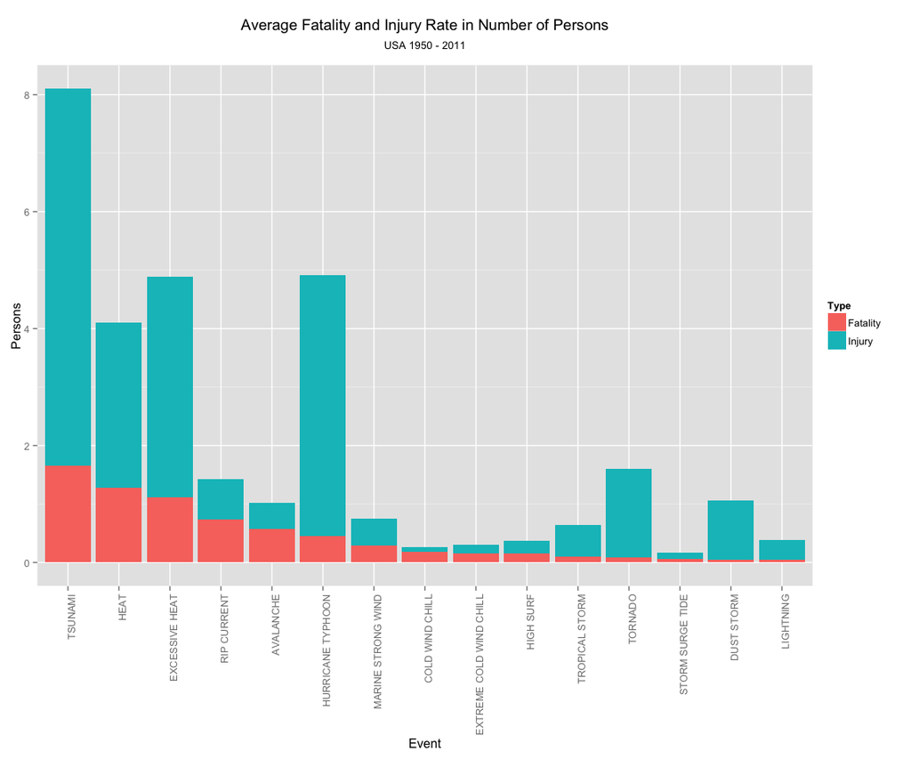

```r
melted <- melt(summarized[,c(1,4,6)], c("EVTYPE"))
melted$EVTYPE <- factor(summarized$EVTYPE,levels=summarized$EVTYPE)
qplot(data = melted, x = EVTYPE, y = value, fill = variable, geom = "bar", stat="identity") + geom_bar(size=.3, stat="identity") + theme(axis.text.x = element_text(angle = 90, hjust = 1)) +  ylab("Persons") + xlab("Event") + ggtitle(expression(atop("Average Fatality and Injury Rate in Number of Persons", atop("USA 1950 - 2011")))) + scale_fill_discrete(name="Type", labels=c("Fatality", "Injury"))
```

#### Property and Crops

```r
grp_dmg <- filter(d, PROPDMG > 0 | CROPDMG > 0) %>% group_by(EVTYPE)
summarized_dmg <- mutate(grp_dmg, prop_dmg = PROPDMG*10^PROPDMGEXP, crop_dmg = CROPDMG*10^CROPDMGEXP) %>% summarize(count = n(), total_prop_dmg = sum(prop_dmg) / 10^9, total_crop_dmg = sum(crop_dmg) / 10^9) %>% mutate(sub_total_dmg = total_prop_dmg + total_crop_dmg) %>% arrange(desc(sub_total_dmg))
summarized_dmg <- summarized_dmg[1:15,]
summarized_dmg
```

```
## Source: local data frame [15 x 5]
##
##               EVTYPE  count total_prop_dmg total_crop_dmg sub_total_dmg
## 1              FLOOD  10510     150.170128     10.8478059    161.017934
## 2  HURRICANE TYPHOON    221      85.256410      5.5061178     90.762528
## 3            TORNADO  39384      57.003318      0.4149605     57.418278
## 4   STORM SURGE TIDE    220      47.964724      0.0008550     47.965579
## 5        FLASH FLOOD  21283      17.589807      1.5321972     19.122004
## 6               HAIL  26000      15.736566      3.0469376     18.783503
## 7            DROUGHT    267       1.046306     13.9726160     15.018922
## 8  THUNDERSTORM WIND 117603      12.775732      1.2570980     14.032830
## 9          ICE STORM    697       3.959104      5.0221143      8.981219
## 10    TROPICAL STORM    412       7.714391      0.6948960      8.409287
## 11         HIGH WIND   6139       6.172246      0.7023829      6.874628
## 12      WINTER STORM   1391       6.689497      0.0274440      6.716941
## 13          WILDFIRE    778       4.765114      0.2954728      5.060587
## 14        HEAVY RAIN   1106       3.249741      0.8061528      4.055893
## 15      FROST FREEZE    155       0.019200      1.9970610      2.016261
```

Following figure depicts the total damage to properties and crops of the 15 most destructive events. Figures are given in billions of USD.

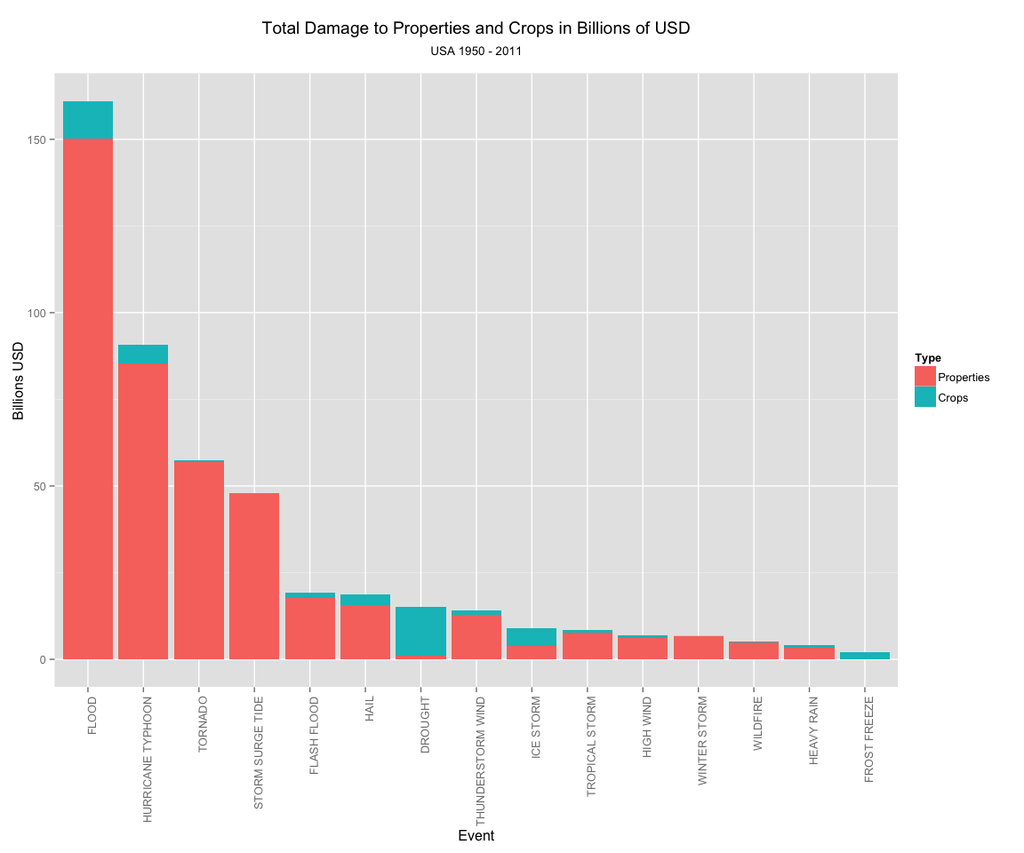

```r
e_factor <- factor(summarized_dmg$EVTYPE,levels=summarized_dmg$EVTYPE)
melted <- melt(summarized_dmg[,c(1,3,4)], c("EVTYPE"))
melted$EVTYPE <- e_factor
qplot(data = melted, x = EVTYPE, y = value, fill = variable, geom = "bar", stat="identity") + geom_bar(stat="identity", size=.3) + theme(axis.text.x = element_text(angle = 90, hjust = 1)) +  ylab("Billions USD") + xlab("Event") + ggtitle(expression(atop("Total Damage to Properties and Crops in Billions of USD", atop("USA 1950 - 2011")))) + scale_fill_discrete(name="Type", labels=c("Properties", "Crops"))
```